# Basic Statistical Models

This notebook outlines my process of generating basic statistical models and exploratory data analysis. This notebook is dependent on the data table gameInfo generated from DataExtraction.RMD.

# Packages

```r
library(sjPlot)
```

# Empty Lists to Store Results

```r
results <- list(
  models = list(),
  plots = list()
)
data.temp <- list()
```

# Vision Score

Let’s examine the effect of vision score on predicted probability of winning. If the theory is true that controlling vision is integral for winning (which by all intuition it should be) then higher vision score should increase the log odds of victory. ## Just Vision Score

```r
summary(results$models$visionScore)
```

```
Call:
glm(formula = win ~ visionScore, family = "binomial", data = gameInfo)

Deviance Residuals:
    Min       1Q   Median       3Q      Max
-1.9622  -1.1513  -0.2429   1.1914   1.2745

Coefficients:
              Estimate Std. Error z value Pr(>|z|)
(Intercept) -0.2254102  0.0040359  -55.85   <2e-16 ***
visionScore  0.0096274  0.0001385   69.50   <2e-16 ***
---
Signif. codes:  0 ‘***’ 0.001 ‘**’ 0.01 ‘*’ 0.05 ‘.’ 0.1 ‘ ’ 1

(Dispersion parameter for binomial family taken to be 1)

    Null deviance: 945480  on 682019  degrees of freedom
Residual deviance: 940520  on 682018  degrees of freedom
AIC: 940524

Number of Fisher Scoring iterations: 4
```

```r
results$plots$visionScore <- plot_model(results$models$visionScore, type = "pred", grid = F)
```

```
Data were 'prettified'. Consider using `terms="visionScore [all]"` to get smooth plots.
```

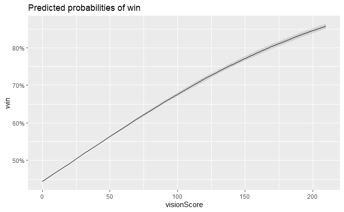

```r
results$plots$visionScore
```

So as expected, increasing vision score *does* appear to increase your chances of victor. So for every point of vision score, the log odds of winning increases by 0.0096 and at a vision score of ~23.4, your win chance is 50%. But what if we wanted to include role (adc, support, etc.)? Is it more important for a particular role to have a high vision score? It should be noted that the average and standard deviation of vision score is 23.49 and 19.96 respectively, so the large vision scores above 100 are very rare and the win rate should not be taken as accurate.

## Include Role

```r
results$models$visionScore.role <- glm(win ~ visionScore*individualPosition, family = "binomial", data = gameInfo %>% filter(individualPosition != "Invalid"))

summary(results$models$visionScore.role)
```

```
Call:
glm(formula = win ~ visionScore * individualPosition, family = "binomial",
    data = gameInfo %>% filter(individualPosition != "Invalid"))

Deviance Residuals:
    Min       1Q   Median       3Q      Max
-2.4343  -1.1539   0.7172   1.1776   1.3968

Coefficients:
                                       Estimate Std. Error z value Pr(>|z|)
(Intercept)                          -0.4334489  0.0117634 -36.847  < 2e-16 ***
visionScore                           0.0095649  0.0002294  41.692  < 2e-16 ***
individualPositionBOTTOM              0.0158948  0.0161149   0.986    0.324
individualPositionMIDDLE             -0.0057545  0.0165318  -0.348    0.728
individualPositionJUNGLE             -0.0688483  0.0165850  -4.151 3.31e-05 ***
individualPositionTOP                 0.0883103  0.0162263   5.442 5.26e-08 ***
visionScore:individualPositionBOTTOM  0.0149763  0.0005965  25.106  < 2e-16 ***
visionScore:individualPositionMIDDLE  0.0160015  0.0006355  25.178  < 2e-16 ***
visionScore:individualPositionJUNGLE  0.0140470  0.0005503  25.525  < 2e-16 ***
visionScore:individualPositionTOP     0.0122536  0.0006491  18.879  < 2e-16 ***
---
Signif. codes:  0 ‘***’ 0.001 ‘**’ 0.01 ‘*’ 0.05 ‘.’ 0.1 ‘ ’ 1

(Dispersion parameter for binomial family taken to be 1)

    Null deviance: 943982  on 680939  degrees of freedom
Residual deviance: 934534  on 680930  degrees of freedom
AIC: 934554

Number of Fisher Scoring iterations: 4
```

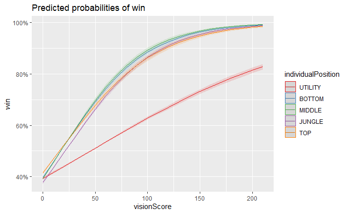

As it turns out, having laners / junglers that ward is a very strong indicator of success. If your laners / jungler have a vision score of less than 25, they are *actively* trolling. Let’s see if we can add time as a covariate to have a more prescriptive intervention that can be made for league players.

## Include Game Time

```r
results$models$visionScore.role.time <- glm(win ~ visionScore*individualPosition*timePlayed, data = gameInfo %>% filter(individualPosition != "Invalid"), family = "binomial")
```

```
Error: cannot allocate vector of size 103.9 Mb
```

```
Error: no more error handlers available (recursive errors?); invoking 'abort' restart
```

# Gold Percentage by Position

It’s a common idea that the ADC role has been considered useless for this season - let’s see what the data has to say about that!

```r
data.temp$goldPercent <- gameInfo %>%
  group_by(match, win) %>% # here win is just used to group team
  mutate(team_gold = sum(goldEarned), goldEarned = goldEarned / team_gold) %>%
  ungroup()

results$models$goldPercent <- glm(win ~ goldEarned*individualPosition, data = data.temp$goldPercent %>% filter(individualPosition != "Invalid"), family = "binomial")

summary(results$models$goldPercent)
```

```
Call:
glm(formula = win ~ goldEarned * individualPosition, family = "binomial",
    data = data.temp$goldPercent %>% filter(individualPosition !=
        "Invalid"))

Deviance Residuals:
   Min      1Q  Median      3Q     Max
-1.323  -1.180   1.097   1.175   1.460

Coefficients:
                                    Estimate Std. Error z value Pr(>|z|)
(Intercept)                          0.59312    0.03422   17.34   <2e-16 ***
goldEarned                          -3.73638    0.21356  -17.50   <2e-16 ***
individualPositionBOTTOM            -0.95585    0.04898  -19.52   <2e-16 ***
individualPositionMIDDLE            -0.52590    0.04799  -10.96   <2e-16 ***
individualPositionJUNGLE            -0.59060    0.04850  -12.18   <2e-16 ***
individualPositionTOP               -0.59217    0.04729  -12.52   <2e-16 ***
goldEarned:individualPositionBOTTOM  5.47693    0.26768   20.46   <2e-16 ***
goldEarned:individualPositionMIDDLE  3.43901    0.26587   12.94   <2e-16 ***
goldEarned:individualPositionJUNGLE  3.67854    0.26801   13.72   <2e-16 ***
goldEarned:individualPositionTOP     3.76405    0.26362   14.28   <2e-16 ***
---
Signif. codes:  0 ‘***’ 0.001 ‘**’ 0.01 ‘*’ 0.05 ‘.’ 0.1 ‘ ’ 1

(Dispersion parameter for binomial family taken to be 1)

    Null deviance: 943982  on 680939  degrees of freedom
Residual deviance: 943546  on 680930  degrees of freedom
AIC: 943566

Number of Fisher Scoring iterations: 3
```

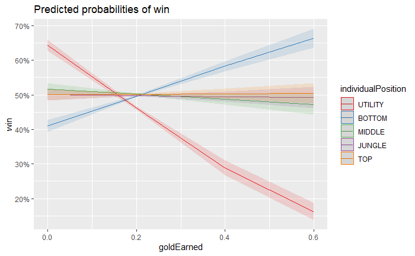

So it would appear that having your carry fed is actually a very strong indicator of win percentage. So why might people believe that ADC is useless? Let’s add tier as a covariate and see what we see. (Also as a note, winrate drops off a cliff if support steals all the gold so good to know…as a support main) ## Add tier

```r
summary(results$models$goldPercent.tier)
```

```
Call:
glm(formula = win ~ goldEarned * individualPosition * tier, family = "binomial",
    data = goldPercent %>% filter(individualPosition != "Invalid"))

Deviance Residuals:
   Min      1Q  Median      3Q     Max
-1.346  -1.179   1.081   1.176   1.492

Coefficients:
                                                   Estimate Std. Error z value Pr(>|z|)
(Intercept)                                       0.7540872  0.0900390   8.375  < 2e-16 ***
goldEarned                                       -4.4437284  0.5216559  -8.519  < 2e-16 ***
individualPositionBOTTOM                         -0.9870719  0.1257502  -7.849 4.18e-15 ***
individualPositionMIDDLE                         -0.8395340  0.1217085  -6.898 5.28e-12 ***
individualPositionJUNGLE                         -0.7553173  0.1208626  -6.249 4.12e-10 ***
individualPositionTOP                            -0.6528942  0.1213688  -5.379 7.47e-08 ***
tierBRONZE                                        0.0008867  0.1291223   0.007 0.994521
tierSILVER                                       -0.0263694  0.1248695  -0.211 0.832750
tierGOLD                                         -0.1054959  0.1243836  -0.848 0.396355
tierPLATINUM                                     -0.3440531  0.1275268  -2.698 0.006978 **
tierDIAMOND                                      -0.2099257  0.1221066  -1.719 0.085578 .
goldEarned:individualPositionBOTTOM               5.7346544  0.6640271   8.636  < 2e-16 ***
goldEarned:individualPositionMIDDLE               4.9490595  0.6498041   7.616 2.61e-14 ***
goldEarned:individualPositionJUNGLE               4.2850081  0.6474130   6.619 3.62e-11 ***
goldEarned:individualPositionTOP                  4.0531294  0.6476428   6.258 3.89e-10 ***
goldEarned:tierBRONZE                            -0.0849957  0.7565685  -0.112 0.910551
goldEarned:tierSILVER                            -0.0440435  0.7426111  -0.059 0.952706
goldEarned:tierGOLD                               0.3153522  0.7529545   0.419 0.675348
goldEarned:tierPLATINUM                           1.7835490  0.7827785   2.278 0.022698 *
goldEarned:tierDIAMOND                            0.8439319  0.7536048   1.120 0.262773
individualPositionBOTTOM:tierBRONZE               0.1114395  0.1799761   0.619 0.535791
individualPositionMIDDLE:tierBRONZE              -0.0803993  0.1743837  -0.461 0.644764
individualPositionJUNGLE:tierBRONZE               0.2750908  0.1755888   1.567 0.117191
individualPositionTOP:tierBRONZE                 -0.3524101  0.1741484  -2.024 0.043009 *
individualPositionBOTTOM:tierSILVER              -0.1903623  0.1751922  -1.087 0.277218
individualPositionMIDDLE:tierSILVER               0.1201389  0.1700873   0.706 0.479979
individualPositionJUNGLE:tierSILVER               0.1484385  0.1716677   0.865 0.387212
individualPositionTOP:tierSILVER                 -0.1245770  0.1693526  -0.736 0.461970
individualPositionBOTTOM:tierGOLD                -0.1700483  0.1748046  -0.973 0.330657
individualPositionMIDDLE:tierGOLD                 0.4676913  0.1704174   2.744 0.006062 **
```

[output cut: 25 more lines]

```
goldEarned:individualPositionTOP:tierPLATINUM    -1.8674175  0.9549370  -1.956 0.050519 .
goldEarned:individualPositionBOTTOM:tierDIAMOND   0.1081900  0.9315740   0.116 0.907544
goldEarned:individualPositionMIDDLE:tierDIAMOND  -2.5436799  0.9238311  -2.753 0.005898 **
goldEarned:individualPositionJUNGLE:tierDIAMOND   0.3662858  0.9206385   0.398 0.690733
goldEarned:individualPositionTOP:tierDIAMOND     -1.1915075  0.9152201  -1.302 0.192957
---
Signif. codes:  0 ‘***’ 0.001 ‘**’ 0.01 ‘*’ 0.05 ‘.’ 0.1 ‘ ’ 1

(Dispersion parameter for binomial family taken to be 1)

    Null deviance: 943982  on 680939  degrees of freedom
Residual deviance: 943423  on 680880  degrees of freedom
AIC: 943543

Number of Fisher Scoring iterations: 3
```

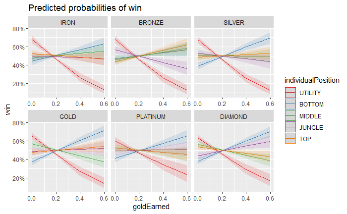

Results are unclear, for lower elo’s *in general*, gold percentage is less important on ADC but it’s not super clear based on the the variance in Silver and Platinum. Interestingly, jungle seems to be a hard carry role in higher elos. Might be because of the champion choice. This will be examined later. # Total Damage Done

```r
summary(results$models$damageDoneChamp)
```

```
Call:
glm(formula = win ~ totalDamageDealtToChampions * individualPosition,
    family = "binomial", data = gameInfo %>% filter(individualPosition !=
        "Invalid"))

Deviance Residuals:
    Min       1Q   Median       3Q      Max
-2.5621  -1.1437   0.6297   1.1823   1.4300

Coefficients:
                                                       Estimate Std. Error z value Pr(>|z|)
(Intercept)                                          -1.946e-01  9.132e-03  -21.31   <2e-16 ***
totalDamageDealtToChampions                           1.711e-05  6.419e-07   26.66   <2e-16 ***
individualPositionBOTTOM                             -3.756e-01  1.428e-02  -26.30   <2e-16 ***
individualPositionMIDDLE                             -3.821e-01  1.459e-02  -26.18   <2e-16 ***
individualPositionJUNGLE                             -2.814e-01  1.389e-02  -20.26   <2e-16 ***
individualPositionTOP                                -3.024e-01  1.452e-02  -20.82   <2e-16 ***
totalDamageDealtToChampions:individualPositionBOTTOM  1.429e-05  8.256e-07   17.31   <2e-16 ***
totalDamageDealtToChampions:individualPositionMIDDLE  1.244e-05  8.207e-07   15.16   <2e-16 ***
totalDamageDealtToChampions:individualPositionJUNGLE  1.123e-05  8.450e-07   13.29   <2e-16 ***
totalDamageDealtToChampions:individualPositionTOP     1.019e-05  8.384e-07   12.15   <2e-16 ***
---
Signif. codes:  0 ‘***’ 0.001 ‘**’ 0.01 ‘*’ 0.05 ‘.’ 0.1 ‘ ’ 1

(Dispersion parameter for binomial family taken to be 1)

    Null deviance: 943982  on 680939  degrees of freedom
Residual deviance: 930273  on 680930  degrees of freedom
AIC: 930293

Number of Fisher Scoring iterations: 4
```

```r
results$plots$damageDoneChamp <- plot_model(damageDoneChamp.fit, type = "int")
```

```
Data were 'prettified'. Consider using `terms="totalDamageDealtToChampions [all]"` to get smooth plots.
```

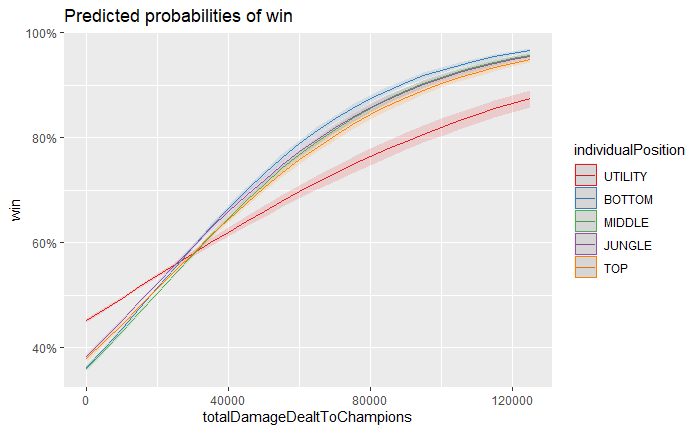

```r
results$plots$damageDoneChamp
```

Not much difference based on whoever does damage to champion aside from support. ## Average Total Damage and Damage to Champions based on Role

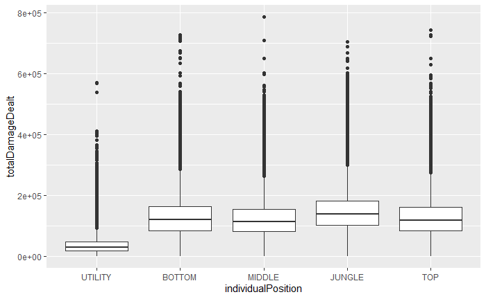

```r
data.temp$damageDone <- gameInfo %>%
  filter(individualPosition != "Invalid") %>%
  select(individualPosition, totalDamageDealtToChampions, totalDamageDealt)
data.temp$damageDone %>%
  ggplot(aes(x = individualPosition, y = totalDamageDealt)) +
  geom_boxplot()
```

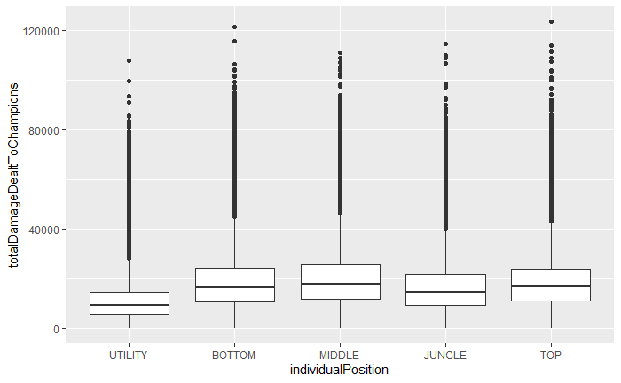

```r
data.temp$damageDone %>%
  ggplot(aes(x = individualPosition, y = totalDamageDealtToChampions)) +
  geom_boxplot()
```

```r
data.temp$damageDone %>%
  filter(individualPosition != "Invalid") %>%
  group_by(individualPosition) %>%
  summarize(avg_damage_champ = mean(totalDamageDealtToChampions), avg_damage_total = mean(totalDamageDealt))
```

| individualPosition | avg_damage_champ | avg_damage_total |
| --- | --- | --- |
| UTILITY | 11515.60 | 38040.88 |
| BOTTOM | 18641.35 | 128330.14 |
| MIDDLE | 19790.09 | 122449.69 |
| JUNGLE | 16535.02 | 144796.76 |
| TOP | 18542.01 | 126381.15 |

## Kruskal-Wallis Test

```r
kruskal.test(totalDamageDealt~individualPosition, data = data.temp$damageDone)
```

```
    Kruskal-Wallis rank sum test

data:  totalDamageDealt by individualPosition
Kruskal-Wallis chi-squared = 245961, df = 4, p-value < 2.2e-16
```

```r
pairwise.wilcox.test(data.temp$damageDone$totalDamageDealt, data.temp$damageDone$individualPosition, p.adjust.method = "fdr")
```

```
    Pairwise comparisons using Wilcoxon rank sum test with continuity correction

data:  data.temp$damageDone$totalDamageDealt and data.temp$damageDone$individualPosition

       UTILITY BOTTOM  MIDDLE  JUNGLE
BOTTOM < 2e-16 -       -       -
MIDDLE < 2e-16 < 2e-16 -       -
JUNGLE < 2e-16 < 2e-16 < 2e-16 -
TOP    < 2e-16 4.3e-07 < 2e-16 < 2e-16

P value adjustment method: fdr
```

Not really useful, sample size is so large which makes any small difference significant. Visual analysis of boxplots probably more useful.

# Champion Difficulty

```r
summary(results$models$championDifficulty)
```

```
Call:
glm(formula = win ~ difficulty * tier, family = "binomial", data = championDifficulty)

Deviance Residuals:
   Min      1Q  Median      3Q     Max
-1.200  -1.177   1.155   1.178   1.199

Coefficients:
                          Estimate Std. Error z value Pr(>|z|)
(Intercept)              0.0280462  0.0190525   1.472    0.141
difficulty              -0.0047378  0.0033087  -1.432    0.152
tierBRONZE              -0.0047720  0.0267433  -0.178    0.858
tierSILVER               0.0374095  0.0256435   1.459    0.145
tierGOLD                 0.0001607  0.0252361   0.006    0.995
tierPLATINUM            -0.0062169  0.0255964  -0.243    0.808
tierDIAMOND             -0.0101555  0.0243362  -0.417    0.676
difficulty:tierBRONZE    0.0006343  0.0046172   0.137    0.891
difficulty:tierSILVER   -0.0069038  0.0043887  -1.573    0.116
difficulty:tierGOLD     -0.0001991  0.0042983  -0.046    0.963
difficulty:tierPLATINUM  0.0008617  0.0043307   0.199    0.842
difficulty:tierDIAMOND   0.0015299  0.0041252   0.371    0.711

(Dispersion parameter for binomial family taken to be 1)

    Null deviance: 924941  on 667203  degrees of freedom
Residual deviance: 924914  on 667192  degrees of freedom
AIC: 924938

Number of Fisher Scoring iterations: 3
```

Hard to say - I might have expected that win rate of difficult champions would increase, hard to say - difficulty does not take into account meta and other interactions. Will look at champion statistics next.